# atividade4

Maria Eduarda Jannoni_atividade4

2025-06-04

#Introdução

A Fotoidentificação (foto-ID) é um método em que a identificação dos indivíduos ocorre através de características e marcas naturais do corpo do animal, e é feita através de fotografias ou vídeos (Schofield et al., 2008). Através da identificação de indivíduos dentro de uma população, é possível estudar as taxas de crescimento, estrutura etária, sobrevivência, residência, distribuição, padrões de movimento e tamanho da população, que são informações importantes para estudos ecológicos e comportamentais (Wells and Scott., 1990; Wilson et al., 2006; Holmberg et al., 2009; Bjorndal et al., 2013). A identificação fotográfica é um método de marcação e recaptura não invasivo e de baixo custo. Os métodos de Foto-ID desenvolvidos para tartarugas marinhas utilizam principalmente a comparação visual de fotografias dos perfis faciais (Rodriguez & Martinez., 2000; Reisser et al., 2008; Schofield et al., 2008). O uso das duas laterais da cabeça das tartarugas assegura uma caracterização mais detalhada e efetiva (Jean et al., 2010), entretanto, caso as duas laterais não estejam disponíveis, é importante considerar essa limitação para a contagem dos indivíduos (Su et al., 2015).

Esse banco de dados é de um resultado de um projeto de Ciência cidadã (https://www.instagram.com/mardetartaruga/). Projeto que atua em Arraial do Cabo e em Fernando de Noronha. O banco de dados disponibilizado abrange somente a Ilha de Fernando de Noronha.

Os dados podem ser encontrados no [Internet of Turtles](https://iot.wildbook.org/) procurando pelo ID “maria”. Para esse trabalho foram extraídos os encontros (avistamento de um único animal em um local e horário específicos) registrados até a abril de 2025.

#Carregar pacotes

```r
library(readxl)
library(tidyverse)
library(stringr)
library(psych)
library(lubridate)
library(plyr)
library(ggnewscale)
library(geobr)
library(readr)
library(plotly)
library(ggpubr)
```

#Definir cores de gráficos e linhas

```r
colors <- c ("#2B78E7", "#B6176E", "#efefef")
colors2 <- c("#7e9700", "#712a78", "#747474")
colors3 <- c ("#2B78E7", "#B6176E")
colors4 <- c ("#7e9700", "#712a78")
```

#lendo o banco de dados

```r
originalenctable <- read_excel("AnnotnExp_2025-04-22.xlsx")
```

#Deletar colunas —-

```r
colnames(originalenctable)
```

```
##  [1] "Occurrence.occurrenceID"
##  [2] "Encounter.sourceUrl"
##  [3] "Encounter.mediaAsset0"
##  [4] "Encounter.mediaAsset1"
##  [5] "Encounter.mediaAsset2"
##  [6] "Encounter.mediaAsset3"
##  [7] "Annotation0.ViewPoint"
##  [8] "Annotation1.ViewPoint"
##  [9] "Annotation2.ViewPoint"
## [10] "Annotation3.ViewPoint"
## [11] "Name0.label"
## [12] "Name0.value"
## [13] "Name1.label"
## [14] "Name1.value"
## [15] "Name2.label"
```

[output cut: 43 more lines]

```r
originalenctable <- read_excel("AnnotnExp_2025-04-22.xlsx") %>%
  select(Name0.value, Occurrence.occurrenceID, Encounter.locationID,
         Encounter.verbatimLocality, Encounter.year, Encounter.month, Encounter.day, Encounter.genus,
         Encounter.specificEpithet, Encounter.occurrenceRemarks,
         Encounter.mediaAsset0.imageUrl, Annotation0.MatchAgainst,
         Encounter.mediaAsset1.imageUrl, Annotation1.MatchAgainst)
originalenctable <- originalenctable %>%
  filter(Encounter.locationID == "Fernando de Noronha")
```

#Configurando a data. Em caso de ausência do dia, foi padronizado uso do dia 15

```r
originalenctable$Encounter.day[originalenctable$Encounter.day==0] <- 15
originalenctable <- unite(originalenctable, Encounter.year, Encounter.month, Encounter.day, col = "Date", sep = "-")
originalenctable$Date <- factor(originalenctable$Date)
originalenctable$Date <- as.Date(originalenctable$Date, format = "%Y-%m-%d")
```

#Definindo qual(is) lateral(is) os indivíduos têm ao longo do banco de dados

```r
tablesides <- originalenctable %>%
  filter(!is.na(Name0.value)) %>%
  group_by(Name0.value) %>%
  dplyr::mutate(Sides = case_when(any(str_detect(Encounter.occurrenceRemarks,"both")|n_distinct(Encounter.occurrenceRemarks) > 1) ~ 'both',
                                  TRUE ~ Encounter.occurrenceRemarks )) %>%
  ungroup
```

#Definindo quais indivíduos já foram revistos

```r
tableresight <- tablesides %>%
  filter(!is.na(Name0.value)) %>%
  group_by(Name0.value) %>%
  dplyr::mutate(Resight = case_when (any(n_distinct(Occurrence.occurrenceID) > 1) ~ 'yes',
                                     TRUE~'no'))
```

#Tabela final com o número total de indivíduos

```r
tableturtlesmax <- tableresight %>%
  filter(!is.na(Name0.value))
```

#Número de fotos que foram avaliadas para criar esse banco de dados

```r
#Gera uma tabela com a quantidade de fotos de tartarugas com uma lateral
tableturtlesmax %>%
  filter(!is.na(Encounter.mediaAsset0.imageUrl)) %>%
  group_by(Encounter.genus) %>%
  dplyr::summarise(n_distinct (Encounter.mediaAsset0.imageUrl))
```

```
## # A tibble: 2 × 2
##   Encounter.genus `n_distinct(Encounter.mediaAsset0.imageUrl)`
##   <chr>                                                  <int>
## 1 Chelonia                                                 574
## 2 Eretmochelys                                             112
```

```r
#Gera uma tabela com a quantidade de fotos de tartarugas com as duas laterais
tableturtlesmax %>%
  filter(!is.na(Encounter.mediaAsset1.imageUrl)) %>%
  group_by(Encounter.genus) %>%
  dplyr::summarise(n_distinct (Encounter.mediaAsset1.imageUrl))
```

```
## # A tibble: 2 × 2
##   Encounter.genus `n_distinct(Encounter.mediaAsset1.imageUrl)`
##   <chr>                                                  <int>
## 1 Chelonia                                                  69
## 2 Eretmochelys                                               9
```

##Como não possuimos todas as laterais de algumas tartarugas, vamos usar a definição de indivíduos únicos para não superestimar a quantidade de indivíduos. #Contando o número de indivíduos distintos para cada espécie, de acordo com a(s) lateral(is) que os indivíduos foram registrados.

```r
tableturtlesmax %>%
  filter(!is.na(Name0.value)) %>%
  filter(Encounter.genus == "Chelonia") %>%
  distinct (Name0.value, .keep_all= TRUE) %>%
  group_by(Sides) %>%
  dplyr::summarise(count = n())
```

```
## # A tibble: 3 × 2
##   Sides count
##   <chr> <int>
## 1 both     50
## 2 left    106
## 3 right   135
```

```r
tableturtlesmax %>%
  filter(!is.na(Name0.value)) %>%
  filter(Encounter.genus == "Eretmochelys") %>%
  distinct (Name0.value, .keep_all= TRUE) %>%
  group_by(Sides) %>%
  dplyr::summarise(count = n())
```

```
## # A tibble: 3 × 2
##   Sides count
##   <chr> <int>
## 1 both     10
## 2 left     42
## 3 right    31
```

#Para evitar possível replicação de indivíduos, é preciso selecionar o número mínimo de indivíduos confirmados. Esse número é o valor dos indivíduos identificados que possuem as duas laterais ‘both’ somado com a lateral que mais possui indivíduos identificados.

Nesse caso ‘right’ para C. mydas e ‘left’ para E. imbricata.

```r
tableturtlesmin <-tableturtlesmax %>%
  filter(!is.na(Name0.value)) %>%
  filter(Sides %in% c('both', 'right') & Encounter.genus == "Chelonia" |
           Sides %in% c('both', 'left') & Encounter.genus == "Eretmochelys")
```

#indivíduos mínimos confirmados #números de fotos

```r
tableturtlesmin %>%
  filter(!is.na(Encounter.mediaAsset0.imageUrl)) %>%
  group_by(Encounter.genus, Resight) %>%
  dplyr::summarise(n_distinct (Encounter.mediaAsset0.imageUrl))
```

```
## # A tibble: 4 × 3
## # Groups:   Encounter.genus [2]
##   Encounter.genus Resight `n_distinct(Encounter.mediaAsset0.imageUrl)`
##   <chr>           <chr>                                          <int>
## 1 Chelonia        no                                               118
## 2 Chelonia        yes                                              299
## 3 Eretmochelys    no                                                39
## 4 Eretmochelys    yes                                               36
```

```r
tableturtlesmin %>%
  filter(!is.na(Encounter.mediaAsset1.imageUrl)) %>%
  group_by(Encounter.genus, Resight) %>%
  dplyr::summarise(n_distinct (Encounter.mediaAsset1.imageUrl))
```

```
## # A tibble: 4 × 3
## # Groups:   Encounter.genus [2]
##   Encounter.genus Resight `n_distinct(Encounter.mediaAsset1.imageUrl)`
##   <chr>           <chr>                                          <int>
## 1 Chelonia        no                                                14
## 2 Chelonia        yes                                               51
## 3 Eretmochelys    no                                                 4
## 4 Eretmochelys    yes                                                4
```

#mostra a quantidade de individuos unicos revistos

```r
tableturtlesmin %>%
  filter(!is.na(Encounter.mediaAsset0.imageUrl)) %>%
  distinct (Name0.value, .keep_all= TRUE) %>%
  group_by(Encounter.genus, Resight) %>%
  dplyr::summarise(count = n())
```

```
## # A tibble: 4 × 3
## # Groups:   Encounter.genus [2]
##   Encounter.genus Resight count
##   <chr>           <chr>   <int>
## 1 Chelonia        no        118
## 2 Chelonia        yes        67
## 3 Eretmochelys    no         39
## 4 Eretmochelys    yes        13
```

#gráfico de individuos unicos revistos

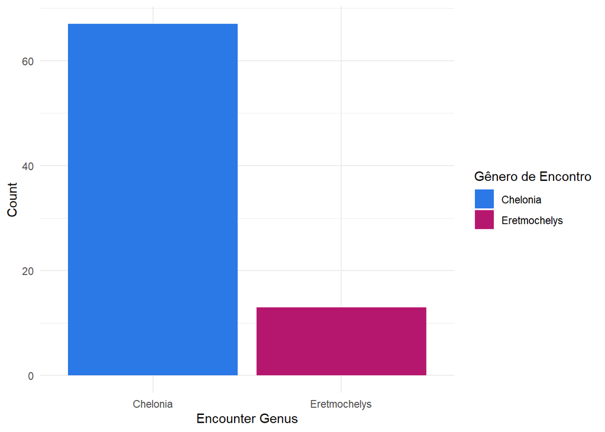

```r
tableturtlesmin %>%
  filter(!is.na(Encounter.mediaAsset0.imageUrl)) %>%
  distinct(Name0.value, .keep_all = TRUE) %>%
  filter(Resight == "yes") %>%
  group_by(Encounter.genus) %>%
  dplyr::summarise(count = n()) %>%
  ggplot(aes(x = Encounter.genus, y = count, fill = Encounter.genus)) +
  geom_bar(stat = "identity") +
  scale_fill_manual(values = c("Chelonia" = "#2b78e7ff", "Eretmochelys" = "#b6176eff")) +
  labs(x = "Encounter Genus", y = "Count", fill = "Gênero de Encontro") +
  theme_minimal()
```

```r
tableturtlesmin %>%
  filter(!is.na(Encounter.mediaAsset1.imageUrl )) %>%
  group_by(Encounter.genus, Resight) %>%
  dplyr::summarise(n_distinct (Encounter.mediaAsset1.imageUrl ))
```

```
## # A tibble: 4 × 3
## # Groups:   Encounter.genus [2]
##   Encounter.genus Resight `n_distinct(Encounter.mediaAsset1.imageUrl)`
##   <chr>           <chr>                                          <int>
## 1 Chelonia        no                                                14
## 2 Chelonia        yes                                               51
## 3 Eretmochelys    no                                                 4
## 4 Eretmochelys    yes                                                4
```

#Filtrar indivíduos revistos

```r
turtlesresighted <- tableturtlesmin %>%
  dplyr::filter(Resight == "yes")
```

#Fotos por mês, intervalo de visualização e filtro de indivíduos

```r
table_sum <- turtlesresighted %>%
  group_by(Date, Name0.value, Encounter.genus) %>%
  dplyr::summarise(count = n()) %>%
  mutate_at(vars(count), funs(factor))
table_range <- table_sum %>%
  group_by(Name0.value, Encounter.genus) %>%
  dplyr::summarise(min = min(Date),
                   max = max(Date)) %>%
  ungroup() %>%
  mutate(diff_dias=max-min) %>%
  mutate(diff_meses=diff_dias/(365.25/12)) %>%
  mutate(diff_anos=diff_dias/(365)) %>%
  mutate_at(vars(diff_meses,diff_anos), round, 1) %>%
  mutate_if(is.difftime,as.numeric)
str(turtlesresighted)
```

[output not shown]

[output cut: 45 more lines]

[output not shown]